# Publication Figure 1

# Libraries

Standard Import

```r
library(tidyverse)
library(cowplot)
library(scales)
library(ggpubr)
```

Special

```r
# devtools::install_github("pmartinezarbizu/pairwiseAdonis/pairwiseAdonis")
library(pairwiseAdonis)
library(FactoMineR)
# library(rgr)
# library(mixOmics)
library(grid)
library(broom)
```

# Paths

```r
bin_dir = '../bin/'
data_dir = '../data/'
results_dir = '../results/'
```

# Custom Scripts / Theme

```r
source(paste0(bin_dir, 'theme_settings.R'))
source (paste0(bin_dir, 'utilities.R'))
source(paste0(bin_dir, 'analysis_metadata.R'))
date <- format(Sys.time(), "%d%m%y")
```

# Import Tables

Metadata

```r
samples.metadata <- read_tsv(paste0(data_dir, 'samples.metadata.tsv'))
microbe.taxonomy <- read_tsv(paste0(data_dir, 'microbe.taxonomy.tsv'))
microbe.metadata <- microbe.taxonomy %>%
  right_join(., read_tsv(paste0(data_dir, 'microbe.metadata.tsv')))
```

## Taxonomy

MetaPhlAn2 tables combine with taxonomy

```r
mp_species.long <- microbe.taxonomy %>%
  right_join(., read_tsv(paste0(data_dir, 'samples.mp_profiles.species.tsv')),
             by = 'species') %>%
  left_join(., samples.metadata, by = 'Name')

mp_species.subsampled.long <- microbe.taxonomy %>%
  right_join(., read_tsv(paste0(data_dir, 'samples.mp_profiles_subsampled.species.tsv')),
             by = 'species') %>%
  left_join(., samples.metadata, by = 'Name')
```

rCDI subset annotate with metadata

```r
mp_species.rcdi.long <-
  mp_species.long %>%
  filter(Study %in% c(rcdi.studies))

mp_species.subsampled.rcdi.long <-
  mp_species.subsampled.long %>%
  filter(Study %in% c(rcdi.studies))
```

## Function

```r
gene_family_annotated <-
  read_tsv(paste0(data_dir, 'genefamilies.infogo1000.cpm.annotated.tsv'))

h2_unstratified <- samples.metadata %>%
  right_join(., read_tsv(paste0(data_dir, 'samples.h2_profiles.unstratified.tsv')),
             by = 'Name')
```

# Set Figure

```r
fig = paste0('Fig_1.')
```

# Taxonomic Composition

PCA analysis of species-level sample composition using data from rCDI recipients, stool donors and post-FMT patients with resolved symptoms

## Format

```r
# filter successful post-FMT samples
failed_samples.Name <-
  samples.metadata %>%
  filter(!fmt_success & Sample_Type == 'post') %>%
  pull(Name)

# transpose
mp_species.rcdi_success.wide <- mp_species.rcdi.long %>%
  filter(kingdom == 'Bacteria') %>%
  filter(!Name %in% failed_samples.Name) %>%
  pivot_wider(id_cols = 'species',
              names_from = 'Name',
              values_from = 'rel_abund',
              values_fill = list(rel_abund = 0))

## -- subsampled
mp_species.subsampled.rcdi_success.wide <- mp_species.subsampled.rcdi.long %>%
  filter(kingdom == 'Bacteria') %>%
  filter(!Name %in% failed_samples.Name) %>%
  pivot_wider(id_cols = 'species',
              names_from = 'Name',
              values_from = 'rel_abund',
              values_fill = list(rel_abund = 0))

## -- genus-level
mp_genus.rcdi_success.wide <- mp_species.rcdi.long %>%
  filter(kingdom == 'Bacteria') %>%
  filter(!Name %in% failed_samples.Name) %>%
  pivot_wider(id_cols = 'genus',
              names_from = 'Name',
              values_from = 'rel_abund',
              values_fill = list(rel_abund = 0),
              values_fn = list(rel_abund = sum))

# get data
mp_species.rcdi_success.data <- t(select(mp_species.rcdi_success.wide,
                                    matches('.pair'), species) %>%
                               column_to_rownames(var = 'species'))

## -- subsampled
mp_species.subsampled.rcdi_success.data <- t(select(mp_species.subsampled.rcdi_success.wide,
                                    matches('.pair'), species) %>%
                               column_to_rownames(var = 'species'))

## -- genus
mp_genus.rcdi_success.data <- t(select(mp_genus.rcdi_success.wide,
                                    matches('.pair'), genus) %>%
                               column_to_rownames(var = 'genus'))
```

## Diversity

Diversity metrics based on species-level relative abundances

### Alpha: Shannon Index

```r
mp_species.raw.rcdi_success.shannon <-
  data.frame(Shannon.raw = diversity(mp_species.rcdi_success.data, index = 'shannon')) %>%
  rownames_to_column('Name')

mp_species.subsampled.rcdi_success.shannon <-
  data.frame(Shannon.subsampled = diversity(mp_species.subsampled.rcdi_success.data, index = 'shannon')) %>%
  rownames_to_column('Name')

mp_species.raw.rcdi_success.shannon <-
  full_join(mp_species.raw.rcdi_success.shannon,
            mp_species.subsampled.rcdi_success.shannon,
            by = 'Name')
```

### CLR-Transform

```r
# species-level
pseudo = 1e-6

mp_species.rcdi_success.clr <- rgr::clr(mp_species.rcdi_success.data + pseudo,  ifclose = FALSE, ifwarn = TRUE)
```

```
  ** Are the data/parts all in the same measurement units? **
```

### Beta: PCA of species-level taxonomic composition

```r
# species-level
mp_species.rcdi_success.clr.pca_data <- PCA(mp_species.rcdi_success.clr, graph = FALSE, scale.unit = F)
mp_species.rcdi_success.clr.pca <- mp_species.rcdi_success.clr.pca_data %>%
  .$ind %>% .$coord %>%
  as.data.frame() %>%
  rownames_to_column(var = 'Name')

## annotate with metadata, diversity
mp_species.rcdi_success.data.clr.pca <- mp_species.rcdi_success.clr.pca %>%
  left_join(., samples.metadata, by = 'Name') %>%
  left_join(., mp_species.raw.rcdi_success.shannon, by = 'Name')
```

Pairwise PERMANOVA (adonis function) testing between rCDI recipients, Donors, and the last available post-FMT sample Showing that composition of rCDI recipient is distinct from donors and post-FMT samples, but last post-FMT time point not different from donors.

```r
mp_species.rcdi_success.data.clr.pca.last <-
  mp_species.rcdi_success.data.clr.pca %>%
  filter(last_sample)

# n count
mp_species.rcdi_success.data.clr.pca.last %>%
  group_by(Sample_Type) %>%
  tally()
```

| Sample_Type | n |
| --- | --- |
| donor | 15 |
| post | 21 |
| recipient | 25 |

```r
rcdi.adonis <-
  pairwise.adonis(
  x = mp_species.rcdi_success.clr[mp_species.rcdi_success.data.clr.pca.last$Name, ],
  factors = mp_species.rcdi_success.data.clr.pca.last$Sample_Type,
  sim.method = 'euclidean',
  p.adjust.m = 'fdr',
  perm = 1e3) %>%
  rename(fdr = p.adjusted) %>%
  mutate(sig = cut(fdr,
                   breaks = c(-Inf, 0.001, 0.01, 0.05, Inf),
                   labels = c("***", "**", "*", "")))
rcdi.adonis
```

| pairs | Df | SumsOfSqs | F.Model | R2 | p.value | fdr | sig |
| --- | --- | --- | --- | --- | --- | --- | --- |
| post vs donor | 1 | 6350.85 | 1.068319 | 0.03046393 | 0.327672328 | 0.327672328 |  |
| post vs recipient | 1 | 21955.30 | 4.053843 | 0.08436043 | 0.000999001 | 0.001498501 | ** |
| donor vs recipient | 1 | 32680.54 | 6.629980 | 0.14855440 | 0.000999001 | 0.001498501 | ** |

PCA Plot shows rCDI recipients clustering separately from post-FMT patients and donors. Separate clustering of MGH03D-related cases is also visible.

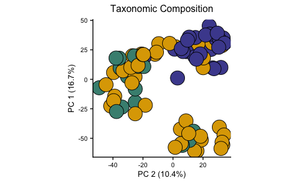

```r
plot <-
  mp_species.rcdi_success.data.clr.pca %>%
  ggplot(aes(-Dim.2, -Dim.1, labels = Unique_ID)) +
  geom_point(shape = 21, size = 8, col = 'black',
  aes(fill = Sample_Type)) +
  scale_fill_manual(values = colors.main) +
  theme_cowplot() +
  labs(y = paste0('PC 1 (', round(mp_species.rcdi_success.clr.pca_data$eig[1,'percentage of variance'], 1), '%)'),
       x = paste0('PC 2 (', round(mp_species.rcdi_success.clr.pca_data$eig[2,'percentage of variance'], 1), '%)'),
       subtitle = 'Taxonomic Composition') +
  theme(plot.title = element_text(hjust = 0.5),
        legend.title=element_blank(),
        aspect.ratio = 1,
        plot.subtitle = element_text(hjust = .5, size = 12),
        axis.title = element_text(size = 10),
        axis.text = element_text(size = 8)
        )
legend <- cowplot::get_legend(plot)

plot + theme(legend.position = 'none')
```

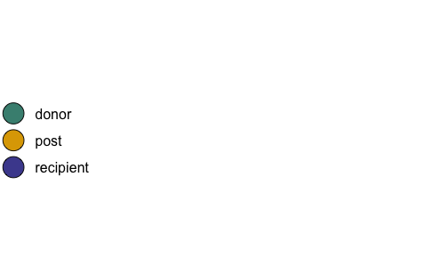

```r
grid.newpage()
grid.draw(legend)
```

Exporting plots, tables

```r
output_name = 'TaxonomicDiversity.SuccessfulCases.CLR_PCA'

ggsave(plot + theme(legend.position = 'none'),
       device = 'pdf', dpi = 300, width = 5, height = 5,
       filename = paste0(results_dir, fig, output_name, '.Plot.pdf'))

ggsave(legend,
       device = 'pdf', dpi = 300, width = 1.1, height = 1,
       filename = paste0(results_dir, fig, output_name, '.Legend.pdf'))

write_tsv(rcdi.adonis, paste0(results_dir, fig, output_name, '.Adonis.tsv'))
```

### Alpha/Beta Correlation

Correlation analysis of Shannon Index with first principal component (PC 1) of PCA analysis shows that large fraction of variance could be explained by alpha diversity differences between samples.

```r
mp_species.rcdi_success.data.clr.pca.cor <-
  cor.test(~ Shannon.raw + Dim.1,
           data = mp_species.rcdi_success.data.clr.pca,
           method = 'spearman') %>%
  broom::tidy(.) %>%
  mutate(estimate.round = round(estimate, 2),
         sig = cut(p.value,
                   breaks = c(-Inf, 0.001, 0.01, 0.05, Inf),
                   labels = c("***", "**", "*", "ns")))
mp_species.rcdi_success.data.clr.pca.cor
```

| estimate | statistic | p.value | method | alternative | estimate.round | sig |
| --- | --- | --- | --- | --- | --- | --- |
| 0.6406504 | 31824 | 0 | Spearman's rank correlation rho | two.sided | 0.64 | *** |

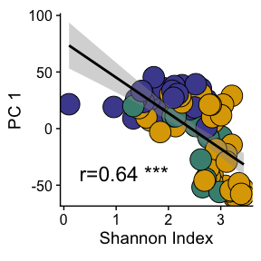

```r
plot <-
  mp_species.rcdi_success.data.clr.pca %>%
  ggplot(aes(Shannon.raw, -Dim.1)) +
  geom_point(shape = 21, col = 'black', size = 8,
  aes(fill = Sample_Type)) +
  geom_smooth(method = 'lm', color = 'black') +
  annotate('text', label = paste0('r=',
                                  mp_species.rcdi_success.data.clr.pca.cor$estimate.round,
                                  ' ',
                                  mp_species.rcdi_success.data.clr.pca.cor$sig),
           x = 1.15, y = -40, size = 6) +
  scale_fill_manual(values = colors.discrete[c(1,2,3)]) +
  theme_cowplot() +
  theme(legend.title=element_blank(),
        aspect.ratio = 1
        ) +
  labs(x = 'Shannon Index', y = 'PC 1')

plot + theme(legend.position = 'none')
```

Exporting plot

```r
output_name = 'TaxonomicDiversity.SuccessfulCases.PC1_Shannon'

ggsave(plot + theme(legend.position = 'none'),
       device = 'pdf', dpi = 300, width = 3, height = 3,
       filename = paste0(results_dir, fig, output_name, '.Plot.pdf'))

ggsave(legend,
       device = 'pdf', dpi = 300, width = 1.1, height = 1,
       filename = paste0(results_dir, fig, output_name, '.Legend.pdf'))
```

Confirming that alpha diversity is representative by comparing Shannon calculated on full and 5M subset of reads generated with seqtk after QC but before MetaPhlAn2.

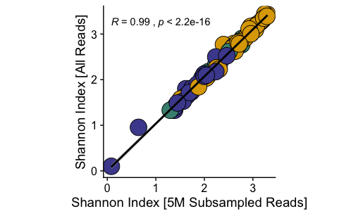

```r
mp_species.rcdi_success.data.clr.pca %>%
  ggplot(aes(Shannon.subsampled, Shannon.raw)) +
  geom_point(shape = 21, col = 'black', size = 8,
  aes(fill = Sample_Type)) +
  geom_smooth(method = 'lm', color = 'black') +
  stat_cor(method = 'spearman') +
  scale_fill_manual(values = colors.discrete[c(1,2,3)]) +
  theme_cowplot() +
  theme(legend.title=element_blank(),
        legend.position = 'none',
        aspect.ratio = 1
        ) +
  labs(x = 'Shannon Index [5M Subsampled Reads]', y = 'Shannon Index [All Reads]')
```

# Taxa Distinguishing Recipients and Donors

## Format

```r
# rcdi_success only excludes failed post-FMT samples
mp_genus.rcdi_success.annotated <-
  samples.metadata %>%
  mutate(tag = paste0(Unique_ID, ' ', gsub(
      gsub(Name, pattern = '.*_', replacement = ''),
                 pattern = '.pair', replacement = ''))) %>%
  right_join(., as.data.frame(mp_genus.rcdi_success.data) %>% rownames_to_column('Name')) %>%
  filter(Sample_Type %in% c('recipient','donor'))
X.metadata <-
  mp_genus.rcdi_success.annotated %>%
  select(Study:tag)

X =
  mp_genus.rcdi_success.annotated %>%
  column_to_rownames(var = 'tag') %>%
  select(-Study:-Study_Type) %>%
  as.data.frame()

Y = as.factor(X.metadata$Sample_Type)
```

## sparse PLS Discriminant Analysis

### Initial sPLS-DA

sPLS-DA of rCDI recipients and donor samples based on genus-level taxonomy

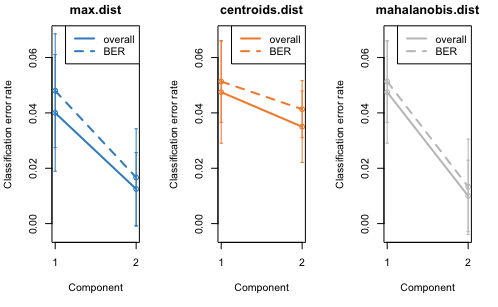

```r
pseudo = 1e-6

data.plsda = mixOmics::plsda(X = X + pseudo, Y, ncomp = nlevels(Y), logratio = 'CLR')
data.perf.plsda = mixOmics::perf(data.plsda, validation = 'Mfold', folds = 5,
                    progressBar = FALSE, nrepeat = 10)

plot(data.perf.plsda, overlay = 'measure', sd=TRUE)
```

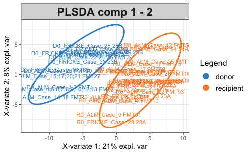

```r
mixOmics::plotIndiv(data.plsda , comp = c(1,2),
          group = Y,
          ind.names = T,
          ellipse = T,
          legend = TRUE, title = 'PLSDA comp 1 - 2')
```

### Cross-Validate features

5x10 CV

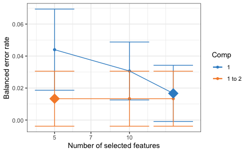

```r
set.seed(100)
data.tune.splsda = mixOmics::tune.splsda(X + pseudo,
                          Y = Y,
                          ncomp = 2,
                          multilevel = NULL,
                          logratio = 'CLR',
                          validation = c('Mfold'),
                          folds = 5,
                          dist = 'max.dist',
                          nrepeat = 10,
                          progressBar = FALSE)

plot(data.tune.splsda)
```

```r
select.keepX = data.tune.splsda$choice.keepX[1:2]
select.keepX # c(15, 5)
```

```
comp1 comp2
   15     5
```

### Apply CV features

```r
data.splsda = mixOmics::splsda(X = X + pseudo,  Y = Y,
                               ncomp = 2,
                               keepX = select.keepX,
                               logratio= "CLR",
                               near.zero.var = T,
)
```

```
Zero- or near-zero variance predictors.
 Reset
            predictors matrix to not near-zero variance predictors.

            See $nzv for problematic predictors.
```

```r
data.perf.splsda = mixOmics::perf(data.splsda, validation = 'Mfold', folds = 5,
                   progressBar = FALSE, nrepeat = 10, dist = 'max.dist')

data.perf.splsda$error.rate
```

```
$overall
      max.dist
comp1    0.005
comp2    0.010

$BER
         max.dist
comp1 0.006666667
comp2 0.010666667
```

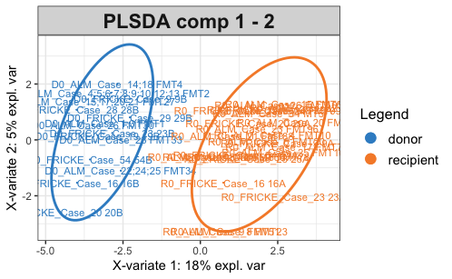

```r
mixOmics::plotIndiv(data.splsda , comp = c(1,2),
          group = Y, ind.names = T,
          ellipse = TRUE, legend = TRUE, title = 'PLSDA comp 1 - 2')
```

Plot loadings and save to table

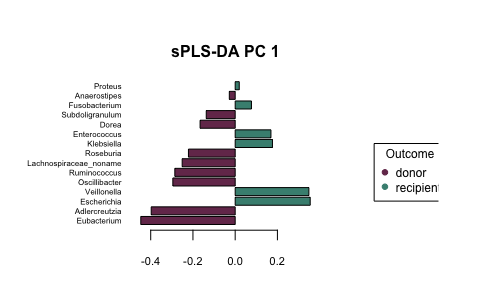

```r
# COMP 1
pL.pc1 <- mixOmics::plotLoadings(data.splsda, title = 'sPLS-DA PC 1',
                       comp = 1, method = 'median', contrib = 'max',
                       size.title = rel(1), border = T,
                       size.name = .5, size.legend = .75,
                       legend.color = colors.discrete[c(4, 1)])
```

```r
pL.pc1
```

|  | donor | recipient | Contrib.donor | Contrib.recipient | Contrib | GroupContrib | color | importance |
| --- | --- | --- | --- | --- | --- | --- | --- | --- |
| Eubacterium | 1.0629162 | -0.7556244 | TRUE | FALSE | FALSE | donor | #75375A | -0.44692817 |
| Adlercreutzia | 1.4534658 | -0.6044442 | TRUE | FALSE | FALSE | donor | #75375A | -0.39760828 |
| Escherichia | -0.9497651 | 0.6973029 | FALSE | TRUE | FALSE | recipient | #478E80 | 0.35525360 |
| Veillonella | -0.8632128 | 0.5006075 | FALSE | TRUE | FALSE | recipient | #478E80 | 0.34901133 |
| Oscillibacter | 1.2980169 | -0.5552579 | TRUE | FALSE | FALSE | donor | #75375A | -0.29521885 |
| Ruminococcus | 1.0253931 | -0.9182839 | TRUE | FALSE | FALSE | donor | #75375A | -0.28580131 |
| Lachnospiraceae_noname | 0.9328293 | -0.9615908 | TRUE | FALSE | FALSE | donor | #75375A | -0.25104166 |
| Roseburia | 0.8818888 | -0.3802837 | TRUE | FALSE | FALSE | donor | #75375A | -0.22130785 |
| Klebsiella | -0.7173461 | 0.3216067 | FALSE | TRUE | FALSE | recipient | #478E80 | 0.17651980 |
| Enterococcus | -0.5884004 | 0.8011480 | FALSE | TRUE | FALSE | recipient | #478E80 | 0.16931337 |

[output cut: 5 more lines]

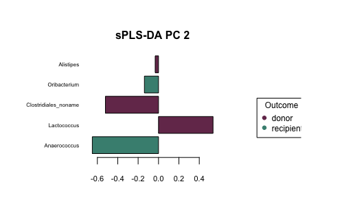

```r
# COMP 2
pL.pc2 <- mixOmics::plotLoadings(data.splsda, title = 'sPLS-DA PC 2',
                       comp = 2, method = 'median', contrib = 'max',
                       size.title = rel(1), border = T,
                       size.name = .5, size.legend = .75,
                       legend.color = colors.discrete[c(4, 1)])
```

```r
pL.pc2
```

|  | donor | recipient | Contrib.donor | Contrib.recipient | Contrib | GroupContrib | color | importance |
| --- | --- | --- | --- | --- | --- | --- | --- | --- |
| Anaerococcus | -0.4186034 | -0.14055044 | FALSE | TRUE | FALSE | recipient | #478E80 | -0.64966130 |
| Lactococcus | 0.4204663 | 0.08747387 | TRUE | FALSE | FALSE | donor | #75375A | 0.53493695 |
| Clostridiales_noname | 0.4152366 | -0.54072619 | TRUE | FALSE | FALSE | donor | #75375A | -0.52110555 |
| Oribacterium | -0.5436339 | -0.05218961 | FALSE | TRUE | FALSE | recipient | #478E80 | -0.13844450 |
| Alistipes | 0.9825883 | -0.64484389 | TRUE | FALSE | FALSE | donor | #75375A | -0.03263096 |

```r
pL <-
  bind_rows(pL.pc1, pL.pc2) %>%
  rownames_to_column('genus') %>%
  rename(rel_abund.recipient.median_clr = recipient,
         rel_abund.donor.median_clr = donor,
         rel_abund.highest = GroupContrib) %>%
  select(genus,
         rel_abund.donor.median_clr,
         rel_abund.recipient.median_clr,
         rel_abund.highest,
         importance)

output_name = 'sPLSDA.DonorRecipient.Loadings'
write_tsv(pL, paste0(results_dir, fig, output_name, '.tsv'))
```

### sPLS-DA: Heatmap

Genera from displayed samples (R/D) in which >=20% of species are predicted orals

```r
genus.oral <-
  mp_species.rcdi.long %>%
  filter(kingdom == 'Bacteria') %>%
  filter(Sample_Type %in% c('recipient', 'donor')) %>%
  left_join(., microbe.metadata %>% select(species, habit.oral), by = 'species') %>%
  mutate(genus = gsub(genus, pattern = '_noname', replacement = '')) %>%
  group_by(genus) %>%
  summarize(oral_rate = replace_na(sum(habit.oral == T, na.rm = T) / n(), NA), .groups = 'drop') %>%
  mutate(oral_genus = oral_rate >= 0.20)
```

Get colors for sample columns and taxa rows

```r
sample_colors <-
  tibble(Unique_ID.splsda = str_split_fixed(data.splsda$names$sample, pattern = ' ', n = 2)[,1]) %>%
  cbind(., mp_genus.rcdi_success.annotated %>% select(tag, Unique_ID, fmt_success, Case_Name, Sample_Type)) %>%
  mutate(color =
        case_when(Sample_Type == 'recipient' ~ colors.discrete[3],
                  Sample_Type == 'donor' ~ colors.discrete[1],
                  T ~ 'white'))

taxa_colors <-
  tibble(genus = gsub(data.splsda$names$colnames$X, pattern = '_noname', replacement = '')) %>%
  left_join(., genus.oral, by = 'genus') %>%
  mutate(color =
        case_when(oral_genus == T ~ 'gray25',
                  oral_genus == F ~ 'gray95',
                  T ~ 'white'))
```

Export Heatmap

```r
output_name = 'sPLSDA.DonorRecipient.Heatmap'
mixOmics::cim(data.splsda,
              row.sideColors = sample_colors$color,
              col.sideColors = taxa_colors$color,
              symkey = T, keysize = c(0.8, 0.8),
              row.names = F,
              col.names = gsub(data.splsda$names$colnames$X, pattern = '_noname', replacement = ''),
              save = 'pdf',
              name.save = paste0(results_dir, fig, output_name),
              margins = c(20, 6.5),
              row.cex = .75, col.cex = .5,
              transpose = T,
              scale = F, center = T)
```

# Oral Species in rCDI recipients

Pulling Oral species from microbe.metadata

```r
oral_species <-
  microbe.metadata %>%
  filter(habit.oral) %>%
  pull(species)
```

## Format

```r
rcdi.oral_species <-
  mp_species.rcdi.long %>%

  filter(last_sample,
         fmt_success | Sample_Type != 'post') %>%
  mutate(oral = species %in% oral_species,
         rel_abund = rel_abund / 100) %>%

  group_by(Case_Name, Sample, Days_Since_FMT, Sample_Type) %>%
  summarize(n = sum(rel_abund > 0, na.rm = T),
            oral = sum(ifelse(species %in% oral_species & rel_abund > 0, 1, 0), na.rm = T),
            species_rel_abund = mean(ifelse(species %in% oral_species & rel_abund > 0, rel_abund, 0), na.rm = T),
            sample_rel_abund = sum(ifelse(species %in% oral_species, rel_abund, 0), na.rm = T),
            ) %>%
  mutate(f = oral / n) %>%

  mutate(source = fct_recode(as.factor(Sample_Type),
              R = 'recipient',
              P = 'post',
              D = 'donor')) %>%
  pivot_longer(names_to = 'metric',
               values_to = 'value',
               cols = c('sample_rel_abund', 'species_rel_abund', 'f'))
```

## Boxplots Oral Taxa

Plot shows enrichment of oral-classified bacteria in rCDI recipients but not donors or controls with decreasing abundances post-FMT.

Cumulative Sample Rel. Abund. of species classified as oral

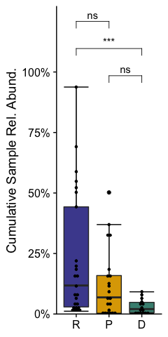

```r
stat_comparisons = list(c('P', 'D'), c('R', 'D'), c('R', 'P'))

plot.sample_rel_abund <-
  rcdi.oral_species %>%
  filter(metric == 'sample_rel_abund') %>%
  ggplot(aes(fct_relevel(source, 'R', 'P', 'D'),
                         value, fill = source)) +
  stat_boxplot(geom = 'errorbar') +
  geom_boxplot(show.legend = F) +
  geom_dotplot(aes(fill = NULL), binaxis = "y",
               stackdir = "center", binpositions="all", binwidth = 0.01) +
  theme_cowplot() +
  scale_y_continuous(labels = percent_format_signif,
                    limits = c(0, 1.21),
                    expand = c(0,0,0.05,0),
                    breaks = c(0, 0.25, 0.5, 0.75, 1)
                     ) +
  scale_fill_manual(values = colors.discrete[c(2,1,3)]) +
  stat_compare_means(method = 'wilcox',
                     comparisons = stat_comparisons,
                     exact = F, p.adjust = 'fdr', label = 'p.signif',
                     symnum.args = list(
                       cutpoints = c(-Inf, 0.001, 0.01, 0.05, Inf),
                       symbols = c("***", "**", "*", "ns"))
                     ) +
  labs(y = 'Cumulative Sample Rel. Abund.') +
  theme(axis.title.x = element_blank())
plot.sample_rel_abund + theme(legend.position = 'none')
```

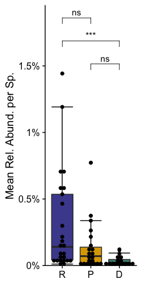

```r
plot.species_rel_abund <-
rcdi.oral_species %>%
  filter(metric == 'species_rel_abund') %>%
  ggplot(aes(fct_relevel(source, 'R', 'P', 'D'),
                         value, fill = source)) +
  stat_boxplot(geom = 'errorbar') +
  geom_boxplot(show.legend = F) +
  geom_dotplot(aes(fill = NULL), binaxis = "y",
               stackdir = "center", binpositions="all", binwidth = 0.00025) +
  theme_cowplot() +
  scale_y_continuous(limits = c(0, NA),
                    labels = percent_format_signif,
                    expand = c(0,0,0.05,0),
                    # breaks = c(0, 0.001, 0.0025, 0.005, 0.01, 0.015)
                     ) +
  scale_fill_manual(values = colors.discrete[c(2,1,3)]) +
  stat_compare_means(method = 'wilcox',
                     comparisons = stat_comparisons,
                     exact = F, p.adjust = 'fdr', label = 'p.signif',
                     symnum.args = list(
                       cutpoints = c(-Inf, 0.001, 0.01, 0.05, Inf),
                       symbols = c("***", "**", "*", "ns"))
                     ) +
  labs(y = 'Mean Rel. Abund. per Sp.') +
  theme(axis.title.x = element_blank())
plot.species_rel_abund + theme(legend.position = 'none')
```

Fraction of Species classified as oral

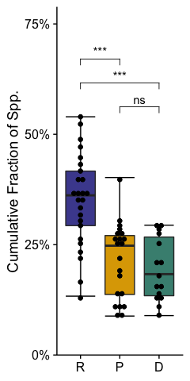

```r
plot.fraction <-
rcdi.oral_species %>%
  filter(metric == 'f') %>%
  ungroup() %>%
  ggplot(aes(fct_relevel(source, 'R', 'P', 'D'),
                         value, fill = source)) +
  stat_boxplot(geom = 'errorbar') +
  geom_boxplot(show.legend = F) +
  geom_dotplot(aes(fill = NULL), binaxis = "y",
               stackdir = "center", binpositions="all", binwidth = 0.01) +
  theme_cowplot() +
  scale_y_continuous(labels = percent_format_signif,
                    limits = c(0, .75),
                    expand = c(0,0,0.05,0),
                    breaks = c(0, 0.25, 0.5, 0.75, 1)
                     ) +
  scale_fill_manual(values = colors.discrete[c(2,1,3)]) +
  stat_compare_means(method = 'wilcox',
                     comparisons = stat_comparisons,
                     exact = F, p.adjust = 'fdr', label = 'p.signif',
                     symnum.args = list(
                       cutpoints = c(-Inf, 0.001, 0.01, 0.05, Inf),
                       symbols = c("***", "**", "*", "ns"))
                     ) +
  theme(axis.title.x = element_blank(),
        legend.title=element_blank(),
        legend.position = 'none',
        strip.background = element_blank()) +
  labs(y = 'Cumulative Fraction of Spp.')

plot.fraction + theme(legend.position = 'none')
```

Exporting plot

```r
output_name = 'OralSpecies'

ggsave(plot.sample_rel_abund + theme(legend.position = 'none'),
       device = 'pdf', dpi = 300, width = 2.5, height = 3.5,
       filename = paste0(results_dir, fig, output_name, '.SampleRelAbund', '.Plot.pdf'))
ggsave(plot.species_rel_abund + theme(legend.position = 'none'),
       device = 'pdf', dpi = 300, width = 2.5, height = 3.5,
       filename = paste0(results_dir, fig, output_name, '.SpeciesRelAbund','.Plot.pdf'))
ggsave(plot.fraction + theme(legend.position = 'none'),
       device = 'pdf', dpi = 300, width = 2.5, height = 3.5,
       filename = paste0(results_dir, fig, output_name, '.SpeciesFraction','.Plot.pdf'))
```

# Oxygen Tolerant Species enriched in rCDI recipients

Summarize over oxygen tolerant species

```r
mp_species.tag.long <-
  samples.metadata %>%
  right_join(., mp_species.long) %>%

  filter(last_sample, !Name %in% failed_samples.Name) %>%
  left_join(., microbe.metadata %>% select(species, oxygen.tolerant), by = 'species') %>%

  mutate(tag = ifelse(is.na(oxygen.tolerant), 'Unknown',
               ifelse(oxygen.tolerant, 'Oxygen Tolerant',
               ifelse(!oxygen.tolerant, 'Oxygen Intolerant', 'Unknown'))),
         tag.bool = !is.na(tag),
         tag = as.factor(tag)) %>%

  group_by(Study_Type, Case_Name, Name, Days_Since_FMT, Sample_Type, tag, fmt_success) %>%
  summarize(rel_abund = sum(rel_abund, na.rm = T)) %>%
  ungroup() %>%

  mutate(tag = fct_relevel(tag, 'Unknown', 'Oxygen Intolerant'))
```

rCDI recipients show high relative abundance of oxygen-tolerant taxa (fac. anaerobes, microaerophiles) compared to donors. Patients do not fully recover down to donor levels after FMT.

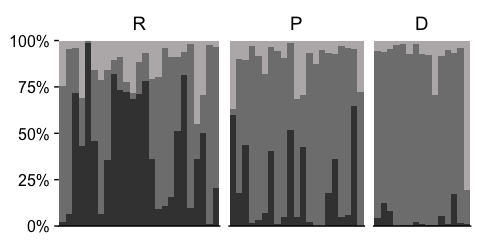

```r
plot <-
  mp_species.tag.long %>%
  filter(Study_Type == 'rCDI') %>%

  mutate(Sample_Type.label = str_to_upper(unlist(str_extract(Sample_Type, pattern = '.')))) %>%
  filter(!Sample_Type.label == 'P' | fmt_success) %>%

  ggplot(aes(fct_reorder(paste0('D', Days_Since_FMT, ' | ', Case_Name), Days_Since_FMT),
    rel_abund / 100,
    fill = tag)) +

   geom_bar(stat = 'identity', position = position_fill(), width = 1)  +
  theme_cowplot() +
  scale_y_continuous(labels = percent_format(),
                     breaks = c(1, .75, .5, .25, 0),
                     expand = c(0,0)) +
  scale_fill_manual(values = c(colors.discrete[10], 'grey50', 'grey25')) +
  theme(axis.title.y = element_blank(),
        axis.title.x = element_blank(),
        axis.line.y = element_blank(),
        axis.text.x = element_blank(),
        axis.ticks.x = element_blank(),
        strip.background = element_blank(),
        strip.text = element_text(size = 14),

        strip.placement = "outside",
        legend.title=element_blank(),
        legend.position = 'bottom') +
    guides(fill=guide_legend(nrow = 1, reverse = T)) +
  facet_grid(cols = vars(fct_relevel(Sample_Type.label, 'R','P','D')),
             scales = 'free_x', space = 'free')
plot + theme(legend.position = 'none')
```

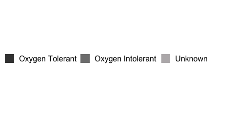

```r
legend <- cowplot::get_legend(plot)

grid.newpage()
grid.draw(legend)
```

```r
output_name = 'OxygenTolerantSpecies'

ggsave(plot + theme(legend.position = 'none'),
       device = 'pdf', dpi = 300, width = 5, height = 2.5,
       filename = paste0(results_dir, fig, output_name, '.Plot.pdf'))
ggsave(legend,
       device = 'pdf', dpi = 300, width = 5, height = 1,
       filename = paste0(results_dir, fig, output_name, '.Legend.pdf'))
```

Control samples are almost exclusively below 1% sample relative abundance.

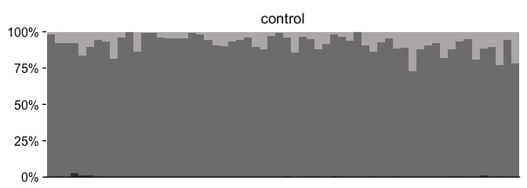

```r
mp_species.tag.long %>%
  filter(Study_Type == 'Control') %>%

  ggplot(aes(fct_reorder(paste0('D', Days_Since_FMT, ' | ', Name), Days_Since_FMT),
    rel_abund / 100,
    fill = tag)) +

   geom_bar(stat = 'identity', width = 1, position = position_fill(),)  +
  theme_cowplot() +
  scale_y_continuous(labels = percent_format(),
                     breaks = c(1, .75, .5, .25, 0),
                     expand = c(0,0)) +
  scale_fill_manual(values = c(colors.discrete[10], 'grey50', 'grey25'),
                    guide = guide_legend(reverse = T)) +
  theme(axis.title.y = element_blank(),
        axis.title.x = element_blank(),
        axis.line.y = element_blank(),
        axis.text.x = element_blank(),
        # axis.text.x = element_text(angle = 90, hjust = 1, size = 2),
        axis.ticks.x = element_blank(),
        strip.background = element_blank(),
        strip.text = element_text(size = 14),
        strip.placement = "outside",
        legend.title=element_blank(),
        legend.position = 'none') +
  facet_grid(cols = vars(Sample_Type),
             scales = 'free_x', space = 'free')
```

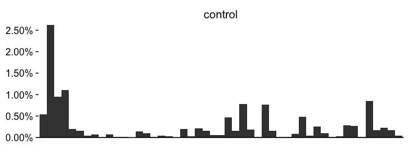

```r
mp_species.tag.long %>%
  filter(Study_Type == 'Control', tag == 'Oxygen Tolerant') %>%

  ggplot(aes(fct_reorder(paste0('D', Days_Since_FMT, ' | ', Name), Days_Since_FMT),
    rel_abund / 100,
    fill = tag)) +

   geom_bar(stat = 'identity', width = 1)  +
  theme_cowplot() +
  scale_y_continuous(labels = percent_format(),
                     expand = c(0,0)) +
  scale_fill_manual(values = 'grey25',
                    guide = guide_legend(reverse = T)) +
  theme(axis.title.y = element_blank(),
        axis.title.x = element_blank(),
        axis.line.y = element_blank(),
        axis.text.x = element_blank(),
        # axis.text.x = element_text(angle = 90, hjust = 1, size = 2),
        axis.ticks.x = element_blank(),
        strip.background = element_blank(),
        strip.text = element_text(size = 14),
        strip.placement = "outside",
        legend.title=element_blank(),
        legend.position = 'none') +
  facet_grid(cols = vars(Sample_Type),
             scales = 'free_x', space = 'free')
```

Pairwise (R/P/D) testing

```r
mp_species.tag.rcdi.long <-
  mp_species.tag.long %>%
  filter(fmt_success | Sample_Type != 'post') %>% # filtering remaining recipients
  filter(Study_Type == 'rCDI', tag == 'Oxygen Tolerant') %>%
  select(Case_Name, Days_Since_FMT, Sample_Type, rel_abund)


plot.testing <- pairwise.wilcox.test(x = mp_species.tag.rcdi.long$rel_abund,
                     g = mp_species.tag.rcdi.long$Sample_Type,
                     paired = F, exact = F, p.adjust.method = 'fdr') %>%
  broom::tidy(.) %>%
  mutate(sig = cut(p.value,
                   breaks = c(-Inf, 0.001, 0.01, 0.05, Inf),
                   labels = c("***", "**", "*", "")))
plot.testing
```

| group1 | group2 | p.value | sig |
| --- | --- | --- | --- |
| post | donor | 2.911374e-02 | * |
| recipient | donor | 2.058925e-05 | *** |
| recipient | post | 4.689068e-03 | ** |

Pairwise (R/P/D) testing paired

```r
mp_species.tag.rcdi.wide <-
  mp_species.tag.rcdi.long %>%
  separate_rows(Case_Name, sep = ';') %>%
  pivot_wider(names_from = 'Sample_Type',
              values_from = 'rel_abund',
              id_cols = 'Case_Name',
              values_fill = list(rel_abund = 0))

mp_species.tag.complete.long <-
  mp_species.tag.rcdi.wide %>%
  pivot_longer(names_to = 'Sample_Type',
               values_to = 'value',
               cols = c('recipient','post','donor'))

plot.testing.paired <- pairwise.wilcox.test(x = mp_species.tag.complete.long$value,
                     g = mp_species.tag.complete.long$Sample_Type,
                     paired = T, exact = F, p.adjust.method = 'fdr') %>%
  broom::tidy(.) %>%
  mutate(sig = cut(p.value,
                   breaks = c(-Inf, 0.001, 0.01, 0.05, Inf),
                   labels = c("***", "**", "*", "")))
plot.testing.paired
```

| group1 | group2 | p.value | sig |
| --- | --- | --- | --- |
| post | donor | 0.1985933984 |  |
| recipient | donor | 0.0001396911 | *** |
| recipient | post | 0.0056871537 | ** |

Exporting plots, tables

```r
output_name = 'OxygenTolerantSpecies'
write_tsv(plot.testing, paste0(results_dir, fig, output_name, '.Testing.PWNP.tsv'))
write_tsv(plot.testing.paired, paste0(results_dir, fig, output_name, '.Testing.PWPP.tsv'))
```

# Functional difference rCDI recipients and donors

Gene-content based Indicators for Oxygen Usage and ABx treatment Plots show increased abundance of these pathways in rCDI recipients, decreasing following FMT treatment.

## Format

```r
# data is in CPM
gf <-
  gene_family_annotated %>%
  separate(Gene_Family, into = c('Gene_Family_Name', 'Taxonomy'),
           sep = '[|]', fill = 'right') %>%
  select(-Taxonomy) %>%

  group_by(Gene_Family_Name) %>%
  summarize_all(.funs = funs(sum(., na.rm = T))) %>%

  group_by(Gene_Family_Name) %>%
  pivot_longer(names_to = 'Name',
               values_to = 'value',
               cols = ends_with(paste0('.pair'))) %>%

  left_join(., samples.metadata, by = 'Name') %>%

  separate(Gene_Family_Name, into = c('Gene_Family_ID', 'Gene_Family_Name'),
           sep = '[:] ', fill = 'right') %>%

  filter(grepl(Gene_Family_Name, pattern = '[[BP]]')) %>%
  filter(last_sample,
         fmt_success | Sample_Type != 'post')
```

[output not shown]

## Microbial oxygen usage

Genes: Aerobic Electron Transport Chain

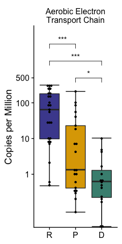

```r
stat_comparisons = list(c('P', 'D'), c('R', 'D'), c('R', 'P'))
pseudo = 1e-2

plot.aerobic <-
gf %>%
  filter(Gene_Family_Name == '[BP] aerobic electron transport chain') %>%
  mutate(GFN = 'Aerobic Electron\nTransport Chain') %>%
  mutate(Sample_Type = str_to_upper(str_extract(Sample_Type, '.'))) %>%
  ggplot(aes(fct_relevel(Sample_Type, 'R','P','D'), value + pseudo, fill = Sample_Type)) +
  stat_boxplot(geom = 'errorbar') +
  geom_boxplot(show.legend = F) +
  geom_dotplot(aes(fill = NULL), binaxis = "y",
               stackdir = "center", binpositions="all", binwidth = 0.05) +

  scale_y_continuous(
                trans = pseudo_log_trans(pseudo, 10),
                expand = c(0,0,0.1,0),
                labels = label_number_si(accuracy = 1),
                breaks = c(1, 10, 100, 500),
                ) +

  facet_wrap(~ GFN, scales = 'free_y', nrow = 2) +
  theme_bw() +
  scale_fill_manual(values = c(colors.discrete[1], colors.discrete[2], colors.discrete[3])) +
  labs(y = 'Copies per Million') +
  theme_cowplot() +
  theme(legend.title=element_blank(),
        legend.position = 'none',
        strip.background = element_blank(),
        axis.title.x = element_blank()
        ) +
  stat_compare_means(method = 'wilcox',
                     comparisons = stat_comparisons,
                     exact = F, p.adjust = 'fdr', label = 'p.signif', symnum.args = list(
                       cutpoints = c(-Inf, 0.001, 0.01, 0.05, Inf),
                       symbols = c("***", "**", "*", "ns"))
                     )
plot.aerobic
```

## ABx response genes

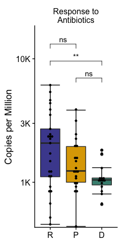

```r
plot.abx <-
  gf %>%
  filter(Gene_Family_Name == '[BP] response to antibiotic') %>%
  mutate(GFN = 'Response to\nAntibiotics') %>%
  mutate(Sample_Type = str_to_upper(str_extract(Sample_Type, '.'))) %>%
  ggplot(aes(fct_relevel(Sample_Type, 'R','P','D'), value + pseudo, fill = Sample_Type)) +
  stat_boxplot(geom = 'errorbar') +
  geom_boxplot(show.legend = F) +
  geom_dotplot(aes(fill = NULL), binaxis = "y",
               stackdir = "center", binpositions="all", binwidth = 0.015) +

  scale_y_continuous(
                trans = pseudo_log_trans(pseudo, 10),
                expand = c(0,0,0.1,0),
                breaks = c(1000, 3000, 10000),
                labels = label_number_si(accuracy = 1)) +

  facet_wrap(~ GFN, scales = 'free_y', nrow = 2) +
  theme_bw() +
  scale_fill_manual(values = c(colors.discrete[1], colors.discrete[2], colors.discrete[3])) +
  labs(y = 'Copies per Million') +
  theme_cowplot() +
  theme(legend.title=element_blank(),
        legend.position = 'none',
        axis.title.x = element_blank(),
        strip.background = element_blank(),
        ) +
  stat_compare_means(method = 'wilcox',
                     comparisons = stat_comparisons,
                     exact = F, p.adjust = 'fdr', label = 'p.signif',
                     symnum.args = list(
                       cutpoints = c(-Inf, 0.001, 0.01, 0.05, Inf),
                       symbols = c("***", "**", "*", "ns"))
                     )
plot.abx
```

Exporting plot

```r
output_name = 'FunctionAerobic'
ggsave(plot.aerobic + theme(legend.position = 'none'),
       device = 'pdf', dpi = 300, width = 2.5, height = 3.5,
       filename = paste0(results_dir, fig, output_name, '.Plot.pdf'))

output_name = 'FunctionABx'
ggsave(plot.abx + theme(legend.position = 'none'),
       device = 'pdf', dpi = 300, width = 2.5, height = 3.5,
       filename = paste0(results_dir, fig, output_name, '.Plot.pdf'))
```

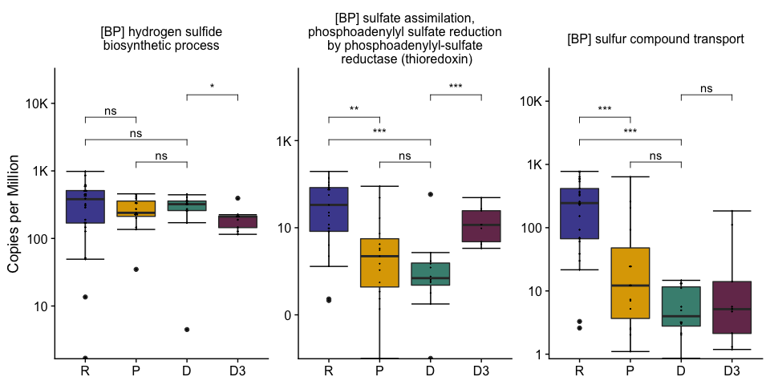

```r
stat_comparisons = list(c('P', 'D'), c('R', 'D'), c('R', 'P'), c('D', 'D3'))

plot.sulf <-
  gf %>%
  filter(Gene_Family_Name %in% c('[BP] hydrogen sulfide biosynthetic process',
                                 '[BP] sulfur compound transport',
                                 '[BP] sulfate assimilation, phosphoadenylyl sulfate reduction by phosphoadenylyl-sulfate reductase (thioredoxin)')) %>%
  mutate(Gene_Family_Name = case_when(
    Gene_Family_Name == '[BP] hydrogen sulfide biosynthetic process' ~ '[BP] hydrogen sulfide\nbiosynthetic process',
    Gene_Family_Name == '[BP] sulfate assimilation, phosphoadenylyl sulfate reduction by phosphoadenylyl-sulfate reductase (thioredoxin)' ~ '[BP] sulfate assimilation,\nphosphoadenylyl sulfate reduction\nby phosphoadenylyl-sulfate\n reductase (thioredoxin)',
    T ~ Gene_Family_Name
  )) %>%

  mutate(GFN = Gene_Family_Name) %>%
  mutate(Sample_Type = str_to_upper(str_extract(Sample_Type, '.'))) %>%
  mutate(Sample_Type = ifelse(Sample_Type != 'R' & Donor.Subject == "D0_ALM_Case_4;5;6;8;9;12;13;15;17;18;20;21", 'D3', Sample_Type)) %>%
  ggplot(aes(fct_relevel(Sample_Type, 'R','P','D'), value + pseudo, fill = Sample_Type)) +
  stat_boxplot(geom = 'errorbar') +
  geom_boxplot(show.legend = F) +
  geom_dotplot(aes(fill = NULL), binaxis = "y",
               stackdir = "center", binpositions="all", binwidth = 0.015) +

  scale_y_log10(expand = c(0,0,0.1,0),
                labels = label_number_si(accuracy = 1)) +

  facet_wrap(~ GFN, nrow = 1, scales = 'free_y') +
  theme_bw() +
  scale_fill_manual(values = c(colors.discrete[c(1,4,2,3)])) +
  labs(y = 'Copies per Million') +
  theme_cowplot() +
  theme(legend.title=element_blank(),
        legend.position = 'none',
        axis.title.x = element_blank(),
        strip.background = element_blank(),
        ) +
  stat_compare_means(method = 'wilcox',
                     comparisons = stat_comparisons,
                     exact = F, p.adjust = 'fdr', label = 'p.signif',
                     symnum.args = list(
                       cutpoints = c(-Inf, 0.001, 0.01, 0.05, Inf),
                       symbols = c("***", "**", "*", "ns"))
                     )
plot.sulf
```

# Functional Composition

PCA analysis of functional composition of rCDI recipients, stool donors and post-FMT patients with resolved symptoms based on clr-transformed pathway relative abundances. Plot shows rCDI recipients clustering separately from donors with less distinct clusters compared to taxonomic data.

## Format

Annotate Humann2 with PWY Classes

```r
h2.rcdi <-
  h2_unstratified %>%
  filter(!Name %in% failed_samples.Name)

h2.rcdi.wide <-
  h2_unstratified %>%
  filter(!Name %in% failed_samples.Name) %>%
  filter(!is.na(pathway_description)) %>%
  reshape2::dcast(., pathway_id + pathway_description ~ Name,
                  value.var = 'CPM', fun.aggregate = sum, na.rm = T)

# transpose
h2.rcdi_success.wide <- h2_unstratified %>%
  filter(!Name %in% failed_samples.Name) %>%
  filter(!is.na(pathway_description)) %>%
  pivot_wider(id_cols = 'pathway_description',
              names_from = 'Name',
              values_from = 'CPM',
              values_fill = list(CPM = 0))

# get data
h2.rcdi_success.data <- t(select(h2.rcdi_success.wide,
                                    matches('.pair'), pathway_description) %>%
                               column_to_rownames(var = 'pathway_description'))
```

## Diversity

### Alpha: Shannon Index

Alpha Diversity

```r
h2.rcdi_success.shannon <- data.frame(Shannon = diversity(h2.rcdi_success.data, index = 'shannon')) %>% rownames_to_column('Name')
```

### CLR-Transform

```r
pseudo = 1e-3 # CPM
h2.rcdi_success.clr <- rgr::clr(h2.rcdi_success.data + pseudo,  ifclose = FALSE, ifwarn = TRUE)
```

```
  ** Are the data/parts all in the same measurement units? **
```

### Beta: PCA of functional composition

```r
h2.rcdi_success.clr.pca_data <- PCA(h2.rcdi_success.clr, graph = FALSE, scale.unit = F)
h2.rcdi_success.clr.pca <- h2.rcdi_success.clr.pca_data %>%
  .$ind %>% .$coord %>%
  as.data.frame() %>%
  rownames_to_column(var = 'Name')

## annotate with metadata, diversity
h2.rcdi_success.data.clr.pca <- h2.rcdi_success.clr.pca %>%
  left_join(., samples.metadata, by = 'Name') %>%
  left_join(., h2.rcdi_success.shannon, by = 'Name')
```

Pairwise PERMANOVA (adonis function) testing between rCDI recipients, Donors, and the last available post-FMT sample Showing that composition of rCDI recipient is distinct from donors and post-FMT samples, but last post-FMT time point not different from donors.

```r
h2.rcdi_success.data.clr.pca.last <-
  h2.rcdi_success.data.clr.pca %>%
  filter(last_sample)

# n count
h2.rcdi_success.data.clr.pca.last %>%
  group_by(Sample_Type) %>%
  tally()
```

| Sample_Type | n |
| --- | --- |
| donor | 15 |
| post | 21 |
| recipient | 25 |

```r
rcdi.adonis <-
  pairwise.adonis(x = h2.rcdi_success.clr[h2.rcdi_success.data.clr.pca.last$Name, ],
  factors = h2.rcdi_success.data.clr.pca.last$Sample_Type,
  sim.method = 'euclidean',
  p.adjust.m = 'fdr',
  perm = 1e3) %>%
  rename(fdr = p.adjusted) %>%
  mutate(sig = cut(fdr,
                   breaks = c(-Inf, 0.001, 0.01, 0.05, Inf),
                   labels = c("***", "**", "*", "")))
rcdi.adonis
```

| pairs | Df | SumsOfSqs | F.Model | R2 | p.value | fdr | sig |
| --- | --- | --- | --- | --- | --- | --- | --- |
| donor vs recipient | 1 | 18866.030 | 9.776254 | 0.20462579 | 0.000999001 | 0.001498501 | ** |
| donor vs post | 1 | 2750.681 | 1.492545 | 0.04205236 | 0.074925075 | 0.074925075 |  |
| recipient vs post | 1 | 11519.068 | 5.546166 | 0.11193936 | 0.000999001 | 0.001498501 | ** |

PCA Plot shows rCDI recipients clustering separately from donors and latest post-FMT patients.

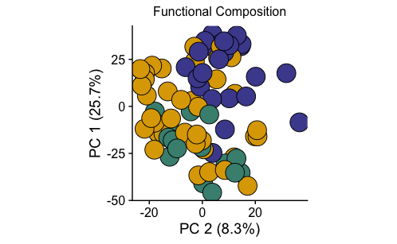

```r
plot <-
  h2.rcdi_success.data.clr.pca %>%

  ggplot(aes(Dim.2, Dim.1, label = Unique_ID)) +
  geom_point(shape = 21, col = 'black', size = 8,
  aes(fill = Sample_Type)) + # Sample_Type
  scale_fill_manual(values = c(colors.discrete[c(1,2,3)]),
                    guide = guide_legend(reverse = TRUE)) +
  theme_cowplot() +
  labs(subtitle = 'Functional Composition') +
  coord_fixed() +
  theme(plot.subtitle = element_text(hjust = 0.5),
        legend.title=element_blank(),
        aspect.ratio = 1
        ) +
  labs(y = paste0('PC 1 (', round(h2.rcdi_success.clr.pca_data$eig[1,'percentage of variance'], 1), '%)'),
       x = paste0('PC 2 (', round(h2.rcdi_success.clr.pca_data$eig[2,'percentage of variance'], 1), '%)'))

legend <- cowplot::get_legend(plot)
plot + theme(legend.position = 'none')
```

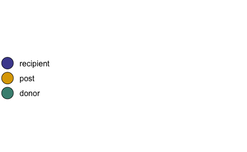

```r
grid.newpage()
grid.draw(legend)
```

Exporting plots, tables

```r
output_name = 'FunctionalDiversity.SuccessfulCases.CLR_PCA'

ggsave(plot + theme(legend.position = 'none'),
       device = 'pdf', dpi = 300, width = 5, height = 5,
       filename = paste0(results_dir, fig, output_name, '.Plot.pdf'))

ggsave(legend,
       device = 'pdf', dpi = 300, width = 1.1, height = 1,
       filename = paste0(results_dir, fig, output_name, '.Legend.pdf'))

write_tsv(rcdi.adonis, paste0(results_dir, fig, output_name, '.Adonis.tsv'))
```